# IE 360 Term Project Report

Group 19: Şirin Yağmur Abacı-Buse Ağlar

07/06/2022

## 1 Introduction

The main purpose of this project is to provide hourly solar power predictions of KIVANC 2 GES (which is located between 36-37° north latitude and 33-35° east longitude) from 25 May 2022 to 2 June 2022, by using the production data given two days prior. Every day the actual hourly solar power production data is updated, and the appropriate forecasting is done for the next day.

In addition to the past production data, four independent variables that are measured at nine different coordinates around the solar panels and on an hourly basis are given. They are listed as temperature data, cloud cover data (in terms of percentage) for low-level type of clouds, downward shortwave radiation flux (DSWRF) data and relative humidity data.

Before working on the forecasting methods, it is essential to analyze the past production data. Time series plot of the production data between 16-22 May 2022 is given below:

```
##             date hour production
## 11491 2022-05-31   18      10.33
## 11492 2022-05-31   19       1.48
## 11493 2022-05-31   20       0.00
## 11494 2022-05-31   21       0.00
## 11495 2022-05-31   22       0.00
## 11496 2022-05-31   23       0.00
```

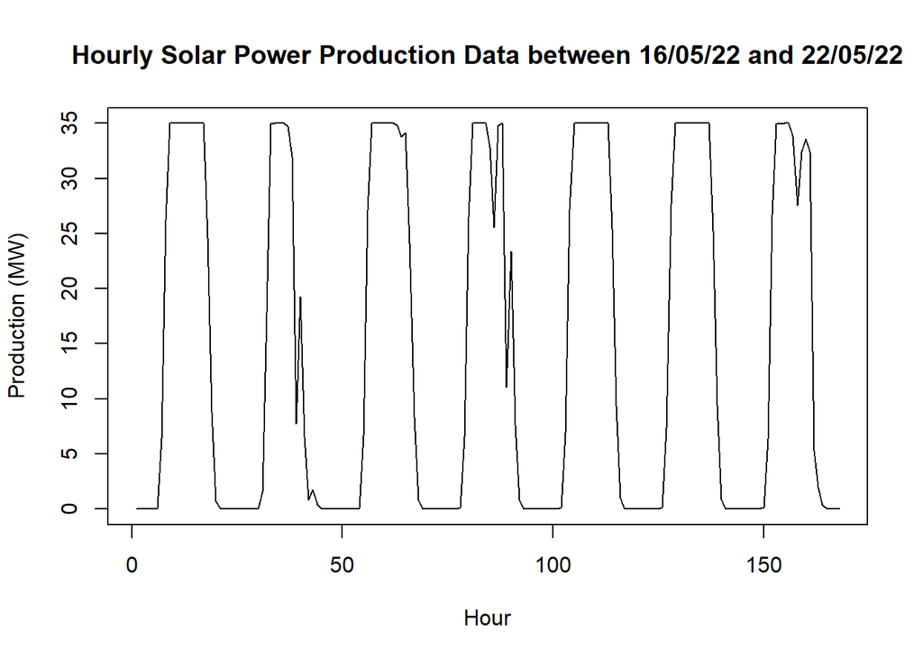

From the plot, it can be seen that hourly solar power production patterns throughout the week are similar. Around midday, the production levels are the highest and in the night hours, the production is zero. It can also be observed that there is a maximum amount of solar power production due to the fact that there is a limit when it comes to the power that the solar panels can produce, which is approximately 35 MW. On 17-19-22 May, the usual pattern is a little bit distorted, which may result from various independent factors affecting the production. For instance, if the clouds cover the solar panels in those days, the expected smooth up-and-down pattern that can be seen in days 16-18-20-21 May cannot be seen. In order to take a look at the data in a more general perspective, hourly solar power production data from 1 February 2021 to 22 May 2022 is plotted below. Since the data is large, x axis does not display the exact hours but instead it displays the months.

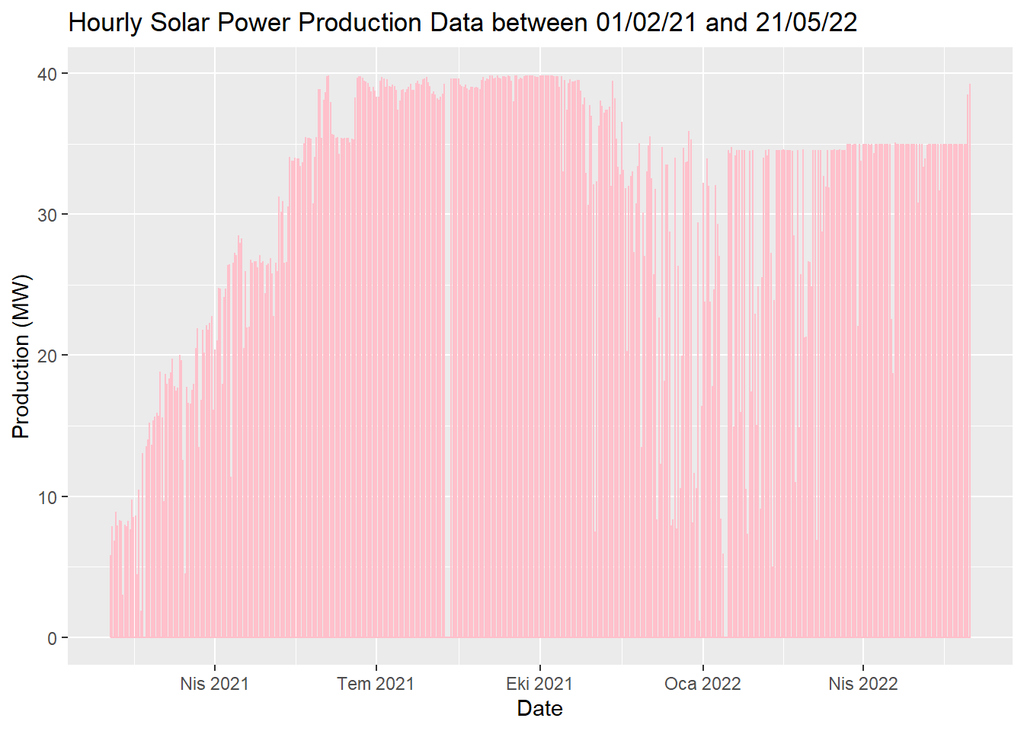

Even though this time series plot might seem crowded, there are multiple observations that can be concluded. First of all, from the weekly graph above, it was concluded that the most probable maximum limit of solar energy production was 35 MW. However, the production data seems to be reaching 40 MW between July-October 2021. This may stem from multiple reasons such as a change in the number of solar panels, or a change in the independent variables which prevent the production from reaching up to its full capacity value.

Secondly, we see an increasing trend from February 2021 to July 2021. The production data starts from 10 MW and then gradually climbs up to 40 MW. One logical reasoning would be that the facility increased the number of solar panels throughout the year.

Around January 2022, the production data seems to differ from the usual pattern. Normally, at midday the production values reach up to 35 MW (which can be seen around April 2022). However, around January 2022, the production data does not always reach up to 35 MW. Since the corresponding time period is winter, it can be said that the independent weather variables play a role in this situation. It is also important to note that some data values are missing in the production data, so the parts where there is zero production does not affect the analysis.

Overall, after thoroughly inspecting the time series plots, it is reasonable to use the hours as seasonality variables and choose significant independent variables after conducting the appropriate analysis. Since most of the time linear regression models tend to perform well compared to the ARIMA models, a regression model is constructed for forecasting in the remaining parts of this report.

## 2 Related Literature

The main sources used in this project were lectures and presentations. In addition, some articles and online resources were used for a more in-depth report. With these resources, the approach to the model, the independent variables that can be added, and the special techniques that can be used for solar energy production are examined. While writing the code, DataCamp website was used. The online resources used in this project are listed below:

1. [DataCamp](https://app.datacamp.com)
2. [Short-Term Solar Power Forecasting: A Combined Long Short-Term Memory and Gaussian Process Regression Method](https://www.mdpi.com/2071-1050/13/7/3665)
3. [Predicting solar generation from weather forecasts using machine learning](https://ieeexplore.ieee.org/abstract/document/6102379?casa_token=eFQl5FFjIOkAAAAA:fXWma1A567smcmNAS_S5C1b2mrdbeMZbMbOhubmw-HEDLAxvdLw7FJ3S8Z9gG1GbjQcqymcvGg)

## 3 Approach

### 3.1 Data Manipulation

Production and weather data were first manipulated in order to be able to model. The first important point in data analysis was that there were different numbers of values in production data and weather data, due to the fact that some days were missing from the production data. In order to create an accurate model, ‘NA’ was added with the pad function instead of missing days. Thus, production and weather data have the same row values on the same days.The reason for the missing days in the production data might be that there was no production on those days due to a malfunction. In addition, the temperature, relative humidity, downward shortwave radiation flux, total cloud cover data given for different coordinates were averaged for each day and added to the data.

```
## pad applied on the interval: hour
```

### 3.2 Model Construction

In this project, 3 different methods were constructed in linear model analysis. In the first method, modeling was done using all hour values from 0 to 23. In the second method, the hours 0,1,2,3,4,20,21,22,23, where the production is always 0 were removed from the model, and modeling was done with the remaining hours. In the third method, 15 different models were obtained by creating a separate model for each of the hours where the production was not 0. The models obtained from these 3 different methods were compared and it was seen that the first method had the best adjusted R-squared value. Since a detailed analysis will be made of the first method, the 2nd and 3rd methods will be examined first.

In the second method, the hours when production was 0 were removed by doing some data manipulations. Similar to the first method, the following plot was obtained.

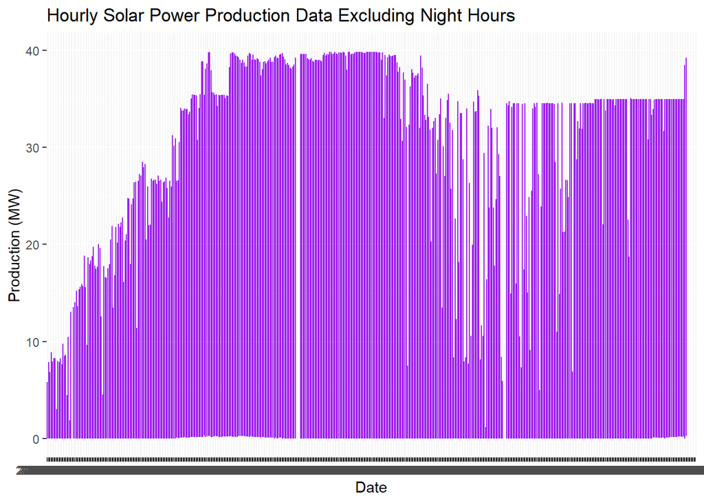

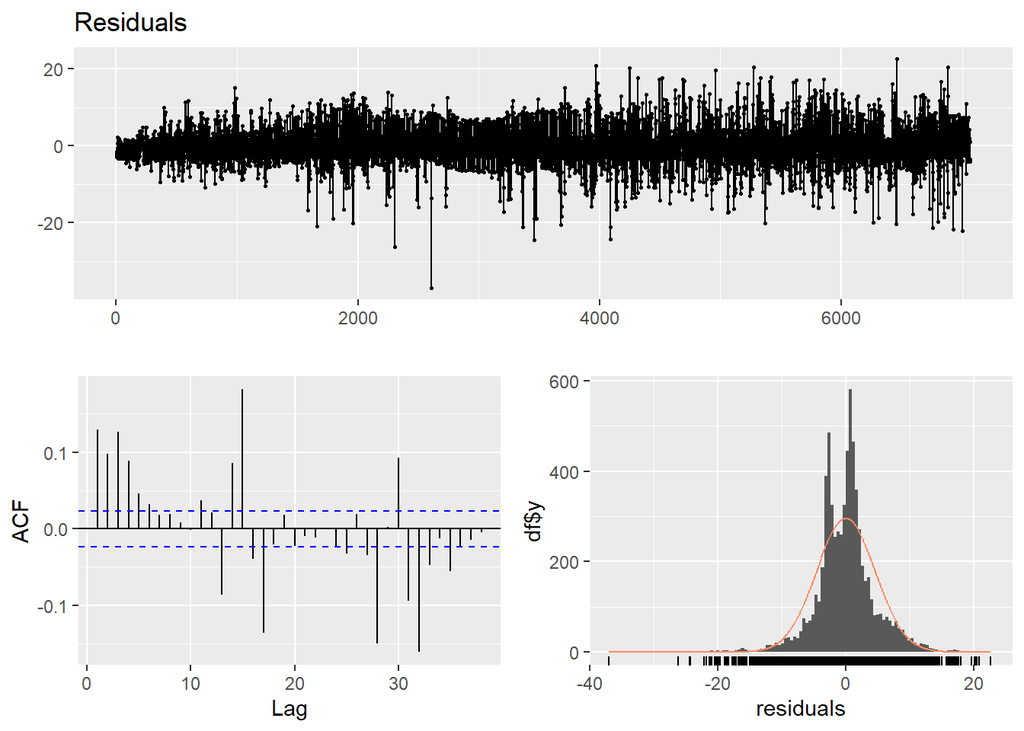

The above model was obtained when modeling was done with independent variables and lagged values for this method.

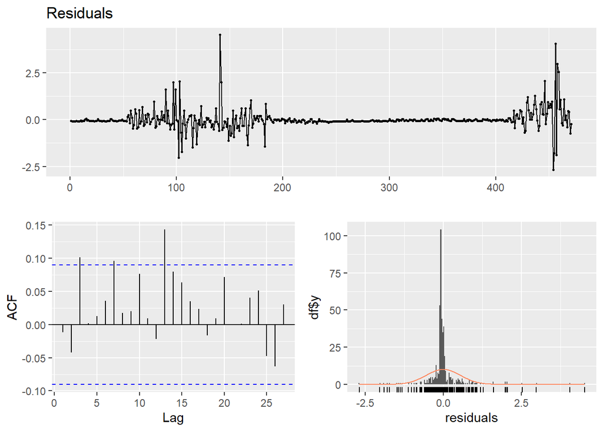

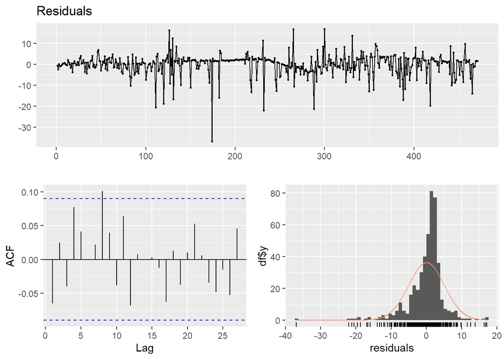

Finally, the last model we used in the predictions will be examined. The data for all hours are used in this model. Hour, lag1, lag2, lag3, lag24, lag30, lag48, mean temperature and mean cloud low layer are used as predictors in the model.

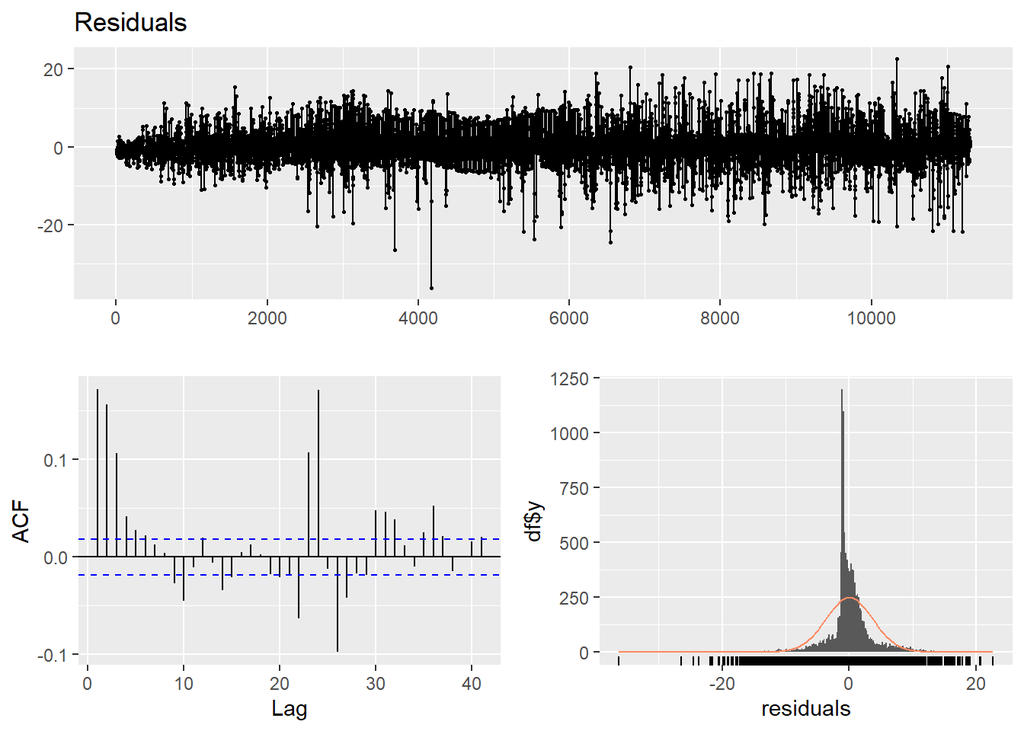

In order to make a comparison, ARIMA model is also displayed below.

```
## Series: dataxts
## ARIMA(0,1,3)
##
## Coefficients:
##          ma1     ma2     ma3
##       0.5736  0.1493  0.0212
## s.e.  0.0093  0.0107  0.0092
##
## sigma^2 = 24.72:  log likelihood = -34745.95
## AIC=69499.91   AICc=69499.91   BIC=69529.31
```

Since AIC value is high and it does not include independent variables, we chose not to proceed with this model.

## 4 Results

```
##
## Call:
## lm(formula = production ~ hour + lag48 + lag24 + lag1 + lag2 +
##     lag3 + lag30 + cloud_mean + TEMP_mean, data = data_weather)
##
## Residuals:
##     Min      1Q  Median      3Q     Max
## -36.252  -1.121  -0.405   1.159  22.645
##
## Coefficients:
##              Estimate Std. Error t value Pr(>|t|)
## (Intercept)  5.672182   1.506079   3.766 0.000167 ***
## hour         0.033434   0.006880   4.860 1.19e-06 ***
## lag48        0.179300   0.006340  28.279  < 2e-16 ***
## lag24        0.248464   0.006589  37.707  < 2e-16 ***
## lag1         0.877681   0.010038  87.434  < 2e-16 ***
## lag2        -0.426273   0.012481 -34.154  < 2e-16 ***
## lag3         0.100564   0.008184  12.288  < 2e-16 ***
## lag30       -0.068474   0.004082 -16.776  < 2e-16 ***
## cloud_mean  -0.027342   0.001511 -18.091  < 2e-16 ***
## TEMP_mean   -0.016493   0.005284  -3.122 0.001804 **
## ---
## Signif. codes:  0 '***' 0.001 '**' 0.01 '*' 0.05 '.' 0.1 ' ' 1
##
## Residual standard error: 3.69 on 11294 degrees of freedom
##   (504 observations deleted due to missingness)
## Multiple R-squared:  0.9341, Adjusted R-squared:  0.934
## F-statistic: 1.778e+04 on 9 and 11294 DF,  p-value: < 2.2e-16
```

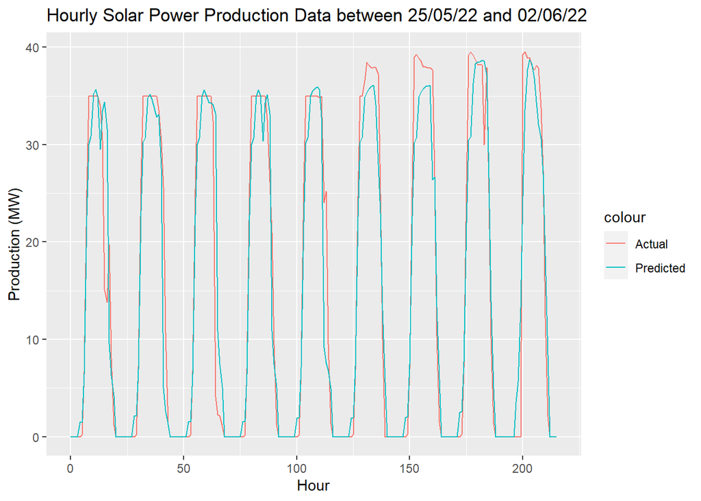

In the final model, all of the regressors are significant. Another important factor to consider in a linear regression model is residual standard error value. This final model has the lowest residual standard error compared to the others derived in the approach section.

According to the plot of the predictions that were made for nine days and their actual values, some days are overpredicted whereas some of them are underpredicted. This is normal considering the fact that there is not a fully accurate model that can predict the future. However, the model does not behave quite well, because in days 1-4-8 large deviations can be seen.

The actual data does not reach past 35 MW in the first five days, however in the remaining days it reaches past 35MW. So it was logical that the data going past 35MW were not modified. On another note, the night hours’ actual production data does not differ much from the predictions, since we replaced the prediction values that correspond to the night hours with zero, after checking the sunrise-sunset times.

Overall, the predictions seem to capture the hourly pattern, even though the unexpected values that can be seen in days 1-4-8. In addition to the graph above, some relevant statistics like bias, WMAPE etc are obtained by placing predicted and actual values in a function called “statistics” to evaluate the estimates.

Statistics for Fitted Hourly Solar Power Production According to Linear Regression Model

| N | Mean | Standard Deviation | Bias | MAD | WMAPE |
| --- | --- | --- | --- | --- | --- |
| 216 | 15.65514 | 16.64106 | 0.0302383 | 2.457115 | 0.1569526 |

From these statistics, it can be understood that the model is a little bit problematic, since it has a WMAPE value of 15.7%. Normally, it is preferred that this value is below 10%.

## 5 Conclusion and Future Work

In conclusion, the final linear regression model is an approximate but not quite accurate model that can predict the hourly solar power production in a satisfactory level. Due to this, further improvements to this model can be made.

First of all, we did not use the DSWRF and relative humidity data, since their mean turned out to be insignificant in the model. Since theoretically they are known to be significant, instead of working with DSWRF mean variable, the most significant DSWRF variable out of nine coordinates could be chosen, and this procedure could also be replicated for the relative humidity as well.

Secondly, more independent variables could be added to the model, other than the ones proposed to us in the project report. However, the data on the internet were not for free, so we could not implement any additional independent variables to the model.

Finally, just as we have manipulated the night hours to be zero manually, we could manipulate the data around midday to not exceed the max capacity value. However since that value is changing throughout the data, as in some days it is 35 MW and some days 40 MW, we did not use this manipulation.

## 6 Code

Corresponding R script and RMD document is given in the progress journal webpage.